# Project: Investigate a Dataset - [TMDb dataset]

## Introduction

### Dataset Description

This data set contains information about 10,000 movies collected from The Movie Database (TMDb), including user ratings and revenue

### Questions for Analysis

- Q1 : What effect does the popularity of a movie have on revenue generation?
- Q2 : Which of the casts have the most popularity?
- Q3 : Who among the casts generated the most revenue?
- Q4 : What are the leading movies based on revenue and budget?

```python
# Import required packages

import pandas as pd
import numpy as np
import seaborn as sns
import matplotlib.pyplot as plt
%matplotlib inline
```

```python
# Upgrade pandas to use dataframe.explode() function.
!pip install --upgrade pandas==0.25.0
!pip install -U seaborn
```

## Data Wrangling

#### Loading dataset into pandas dataframe

```python
# Load your data
df = pd.read_csv('Database_TMDb_movie_data/tmdb-movies.csv')
```

#### View the first five rows of the data

```python
df.head()
```

|  | id | imdb_id | popularity | budget | revenue | original_title | cast | homepage | director | tagline | ... | overview | runtime | genres | production_companies | release_date | vote_count | vote_average | release_year | budget_adj | revenue_adj |
| --- | --- | --- | --- | --- | --- | --- | --- | --- | --- | --- | --- | --- | --- | --- | --- | --- | --- | --- | --- | --- | --- |
| 0 | 135397 | tt0369610 | 32.985763 | 150000000 | 1513528810 | Jurassic World | Chris Pratt\|Bryce Dallas Howard\|Irrfan Khan\|Vi... | http://www.jurassicworld.com/ | Colin Trevorrow | The park is open. | ... | Twenty-two years after the events of Jurassic ... | 124 | Action\|Adventure\|Science Fiction\|Thriller | Universal Studios\|Amblin Entertainment\|Legenda... | 6/9/15 | 5562 | 6.5 | 2015 | 1.379999e+08 | 1.392446e+09 |
| 1 | 76341 | tt1392190 | 28.419936 | 150000000 | 378436354 | Mad Max: Fury Road | Tom Hardy\|Charlize Theron\|Hugh Keays-Byrne\|Nic... | http://www.madmaxmovie.com/ | George Miller | What a Lovely Day. | ... | An apocalyptic story set in the furthest reach... | 120 | Action\|Adventure\|Science Fiction\|Thriller | Village Roadshow Pictures\|Kennedy Miller Produ... | 5/13/15 | 6185 | 7.1 | 2015 | 1.379999e+08 | 3.481613e+08 |
| 2 | 262500 | tt2908446 | 13.112507 | 110000000 | 295238201 | Insurgent | Shailene Woodley\|Theo James\|Kate Winslet\|Ansel... | http://www.thedivergentseries.movie/#insurgent | Robert Schwentke | One Choice Can Destroy You | ... | Beatrice Prior must confront her inner demons ... | 119 | Adventure\|Science Fiction\|Thriller | Summit Entertainment\|Mandeville Films\|Red Wago... | 3/18/15 | 2480 | 6.3 | 2015 | 1.012000e+08 | 2.716190e+08 |
| 3 | 140607 | tt2488496 | 11.173104 | 200000000 | 2068178225 | Star Wars: The Force Awakens | Harrison Ford\|Mark Hamill\|Carrie Fisher\|Adam D... | http://www.starwars.com/films/star-wars-episod... | J.J. Abrams | Every generation has a story. | ... | Thirty years after defeating the Galactic Empi... | 136 | Action\|Adventure\|Science Fiction\|Fantasy | Lucasfilm\|Truenorth Productions\|Bad Robot | 12/15/15 | 5292 | 7.5 | 2015 | 1.839999e+08 | 1.902723e+09 |
| 4 | 168259 | tt2820852 | 9.335014 | 190000000 | 1506249360 | Furious 7 | Vin Diesel\|Paul Walker\|Jason Statham\|Michelle ... | http://www.furious7.com/ | James Wan | Vengeance Hits Home | ... | Deckard Shaw seeks revenge against Dominic Tor... | 137 | Action\|Crime\|Thriller | Universal Pictures\|Original Film\|Media Rights ... | 4/1/15 | 2947 | 7.3 | 2015 | 1.747999e+08 | 1.385749e+09 |

5 rows × 21 columns

#### Printing the last five rows

```python
df.tail()
```

|  | id | imdb_id | popularity | budget | revenue | original_title | cast | homepage | director | tagline | ... | overview | runtime | genres | production_companies | release_date | vote_count | vote_average | release_year | budget_adj | revenue_adj |
| --- | --- | --- | --- | --- | --- | --- | --- | --- | --- | --- | --- | --- | --- | --- | --- | --- | --- | --- | --- | --- | --- |
| 10861 | 21 | tt0060371 | 0.080598 | 0 | 0 | The Endless Summer | Michael Hynson\|Robert August\|Lord 'Tally Ho' B... | NaN | Bruce Brown | NaN | ... | The Endless Summer, by Bruce Brown, is one of ... | 95 | Documentary | Bruce Brown Films | 6/15/66 | 11 | 7.4 | 1966 | 0.000000 | 0.0 |
| 10862 | 20379 | tt0060472 | 0.065543 | 0 | 0 | Grand Prix | James Garner\|Eva Marie Saint\|Yves Montand\|Tosh... | NaN | John Frankenheimer | Cinerama sweeps YOU into a drama of speed and ... | ... | Grand Prix driver Pete Aron is fired by his te... | 176 | Action\|Adventure\|Drama | Cherokee Productions\|Joel Productions\|Douglas ... | 12/21/66 | 20 | 5.7 | 1966 | 0.000000 | 0.0 |
| 10863 | 39768 | tt0060161 | 0.065141 | 0 | 0 | Beregis Avtomobilya | Innokentiy Smoktunovskiy\|Oleg Efremov\|Georgi Z... | NaN | Eldar Ryazanov | NaN | ... | An insurance agent who moonlights as a carthie... | 94 | Mystery\|Comedy | Mosfilm | 1/1/66 | 11 | 6.5 | 1966 | 0.000000 | 0.0 |
| 10864 | 21449 | tt0061177 | 0.064317 | 0 | 0 | What's Up, Tiger Lily? | Tatsuya Mihashi\|Akiko Wakabayashi\|Mie Hama\|Joh... | NaN | Woody Allen | WOODY ALLEN STRIKES BACK! | ... | In comic Woody Allen's film debut, he took the... | 80 | Action\|Comedy | Benedict Pictures Corp. | 11/2/66 | 22 | 5.4 | 1966 | 0.000000 | 0.0 |
| 10865 | 22293 | tt0060666 | 0.035919 | 19000 | 0 | Manos: The Hands of Fate | Harold P. Warren\|Tom Neyman\|John Reynolds\|Dian... | NaN | Harold P. Warren | It's Shocking! It's Beyond Your Imagination! | ... | A family gets lost on the road and stumbles up... | 74 | Horror | Norm-Iris | 11/15/66 | 15 | 1.5 | 1966 | 127642.279154 | 0.0 |

5 rows × 21 columns

In this section I would like to show the number of rows and columns that is contained in the above dataset for analysis

```python
df.shape
```

```
(10866, 21)
```

In defining the shape of the dataset I observed it contained 10,866 rows and 21 columns

#### Exploring the columns and its associated datatypes

```python
df.info()
```

```
<class 'pandas.core.frame.DataFrame'>
RangeIndex: 10866 entries, 0 to 10865
Data columns (total 21 columns):
id                      10866 non-null int64
imdb_id                 10856 non-null object
popularity              10866 non-null float64
budget                  10866 non-null int64
revenue                 10866 non-null int64
original_title          10866 non-null object
cast                    10790 non-null object
homepage                2936 non-null object
director                10822 non-null object
tagline                 8042 non-null object
keywords                9373 non-null object
overview                10862 non-null object
runtime                 10866 non-null int64
genres                  10843 non-null object
production_companies    9836 non-null object
release_date            10866 non-null object
vote_count              10866 non-null int64
vote_average            10866 non-null float64
release_year            10866 non-null int64
budget_adj              10866 non-null float64
revenue_adj             10866 non-null float64
dtypes: float64(4), int64(6), object(11)
memory usage: 1.7+ MB
```

Observation after gaining a bit more information about the dataset showed some of the values were missing from the columns.

### Data Cleaning

In this section I would identify missing values if any to enable me clean the dataset by highlighting duplicates and dropping them

#### Structure of the dataset

```python
df.info()
```

```
<class 'pandas.core.frame.DataFrame'>
RangeIndex: 10866 entries, 0 to 10865
Data columns (total 21 columns):
id                      10866 non-null int64
imdb_id                 10856 non-null object
popularity              10866 non-null float64
budget                  10866 non-null int64
revenue                 10866 non-null int64
original_title          10866 non-null object
cast                    10790 non-null object
homepage                2936 non-null object
director                10822 non-null object
tagline                 8042 non-null object
keywords                9373 non-null object
overview                10862 non-null object
runtime                 10866 non-null int64
genres                  10843 non-null object
production_companies    9836 non-null object
release_date            10866 non-null object
vote_count              10866 non-null int64
vote_average            10866 non-null float64
release_year            10866 non-null int64
budget_adj              10866 non-null float64
revenue_adj             10866 non-null float64
dtypes: float64(4), int64(6), object(11)
memory usage: 1.7+ MB
```

From above we check the dataset to see whether there are any missing values

```python
df.isnull().values.any()
```

```
True
```

With the output being true it confirms there are missing values in the dataset.

Counting the number of missing values

```python
#
df.isnull().values.sum()
```

```
13434
```

I confirmed that there indeed are missing values from the dataset as evidenced above

In the next step at cleaning our dataset we take out all duplicate values by first knowing the sum of them.

This is to give us a definite outlook of what we'll be taking off

#### Checking for duplicates

```python
df.duplicated().sum()
```

```
1
```

From the output above it shows there is only one duplicate in the dataset.

In the next step we would like to investigate which movie specifically has been duplicated

```python
df[df.duplicated()]
```

|  | id | imdb_id | popularity | budget | revenue | original_title | cast | homepage | director | tagline | ... | overview | runtime | genres | production_companies | release_date | vote_count | vote_average | release_year | budget_adj | revenue_adj |
| --- | --- | --- | --- | --- | --- | --- | --- | --- | --- | --- | --- | --- | --- | --- | --- | --- | --- | --- | --- | --- | --- |
| 2090 | 42194 | tt0411951 | 0.59643 | 30000000 | 967000 | TEKKEN | Jon Foo\|Kelly Overton\|Cary-Hiroyuki Tagawa\|Ian... | NaN | Dwight H. Little | Survival is no game | ... | In the year of 2039, after World Wars destroy ... | 92 | Crime\|Drama\|Action\|Thriller\|Science Fiction | Namco\|Light Song Films | 3/20/10 | 110 | 5.0 | 2010 | 30000000.0 | 967000.0 |

1 rows × 21 columns

This give us the indication that Tekken was the movie that was duplicated.

Duplication reduces the quality of our dataset. We hence would have to take that off to make our data set clean.

#### The next few steps will higlight what we would be going through in cleaning our dataset.

```python
# Steps will be taken to remove all duplicates from our dataset.
```

```python
df.drop_duplicates(inplace=True)
```

```python
df.shape
```

```
(10865, 21)
```

From the onset I have been working with 10,866 rows and 21 columns. Now I'm certain the dataset is clean of all duplicates after dropping them This means the new dataset after removing duplicates contains 10865 rows and 21 columns

#### Next up I would like to have a fair idea of the number of null values in each column.

#### I would iterate through the dataset and count for missing values in each column

```python
df.isnull().sum()
```

```
id                         0
imdb_id                   10
popularity                 0
budget                     0
revenue                    0
original_title             0
cast                      76
homepage                7929
director                  44
tagline                 2824
keywords                1493
overview                   4
runtime                    0
genres                    23
production_companies    1030
release_date               0
vote_count                 0
vote_average               0
release_year               0
budget_adj                 0
revenue_adj                0
dtype: int64
```

From the data above I realized some of the columns have missing values.

I realize there are 6 integers, 4 floats and 11 objects. Note object in this space represents strings.

This breakdown in relation to integers, floats and objects gives us a fair idea of the types of datatypes I'll be dealing with in our dataset

For example, if I pick cast after analysis we realize there are 10790 rows out of a total of 10866 meaning it has a total of 76 columns which has missing values

Looking a genre same observation is made as there are 23 missing values.

The same analogy runs through each columns of the dataset.

## Exploratory Data Analysis

### Research Question 1 - What effect does the popularity of a movie have on revenue generation?

We seek to find out how the popularity index in turn affects the revenue generated. We seek to further explore to see the relation between popularity as against revenue?

#### Defining a custom function to plot the graphs

```python
def plot_bargraph(x,y,title,xlabel,ylabel):
    plt.figure(figsize=[12,8])
    sns.barplot(x=x,y=y);
    plt.title(title)
    plt.xlabel(xlabel)
    plt.ylabel(ylabel)
    plt.show()
```

#### Summary Statistics

```python
df.describe()
```

|  | id | popularity | budget | revenue | runtime | vote_count | vote_average | release_year | budget_adj | revenue_adj |
| --- | --- | --- | --- | --- | --- | --- | --- | --- | --- | --- |
| count | 10865.000000 | 10865.000000 | 1.086500e+04 | 1.086500e+04 | 10865.000000 | 10865.000000 | 10865.000000 | 10865.000000 | 1.086500e+04 | 1.086500e+04 |
| mean | 66066.374413 | 0.646446 | 1.462429e+07 | 3.982690e+07 | 102.071790 | 217.399632 | 5.975012 | 2001.321859 | 1.754989e+07 | 5.136900e+07 |
| std | 92134.091971 | 1.000231 | 3.091428e+07 | 1.170083e+08 | 31.382701 | 575.644627 | 0.935138 | 12.813260 | 3.430753e+07 | 1.446383e+08 |
| min | 5.000000 | 0.000065 | 0.000000e+00 | 0.000000e+00 | 0.000000 | 10.000000 | 1.500000 | 1960.000000 | 0.000000e+00 | 0.000000e+00 |
| 25% | 10596.000000 | 0.207575 | 0.000000e+00 | 0.000000e+00 | 90.000000 | 17.000000 | 5.400000 | 1995.000000 | 0.000000e+00 | 0.000000e+00 |
| 50% | 20662.000000 | 0.383831 | 0.000000e+00 | 0.000000e+00 | 99.000000 | 38.000000 | 6.000000 | 2006.000000 | 0.000000e+00 | 0.000000e+00 |
| 75% | 75612.000000 | 0.713857 | 1.500000e+07 | 2.400000e+07 | 111.000000 | 146.000000 | 6.600000 | 2011.000000 | 2.085325e+07 | 3.370173e+07 |
| max | 417859.000000 | 32.985763 | 4.250000e+08 | 2.781506e+09 | 900.000000 | 9767.000000 | 9.200000 | 2015.000000 | 4.250000e+08 | 2.827124e+09 |

Popularity: The popularity index tarts with a minimum of 0.000065, maximum of 32.985763 with a mean of 0.646446

Runtime: There exists a minimum runtime of 0, maximum runtime of 900 and a mean of 102.071790

Release year: The release years starts from 1960 to 2015

#### Scatter plot of all the features

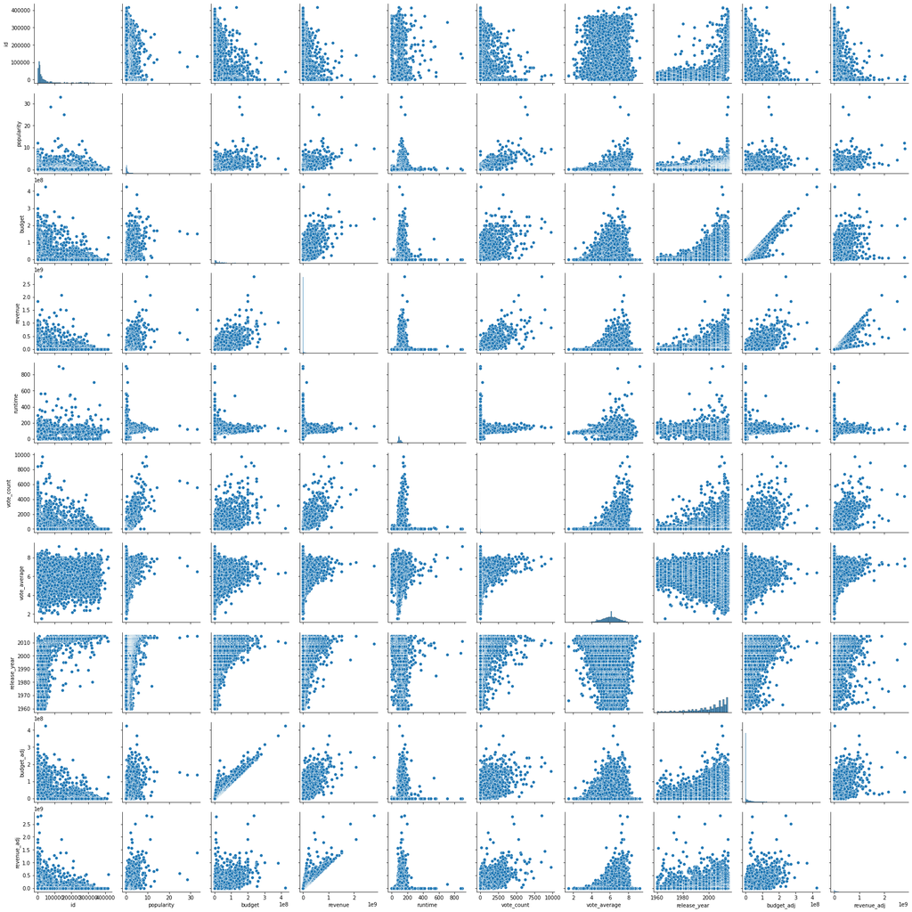

```python
plt.figure(figsize=[15,15])
sns.pairplot(df)
```

```python
df.popularity.describe()
```

```
count    10865.000000
mean         0.646446
std          1.000231
min          0.000065
25%          0.207575
50%          0.383831
75%          0.713857
max         32.985763
Name: popularity, dtype: float64
```

#### We woud hence plot a scatter diagram which would show the relation between popularity and revenue.

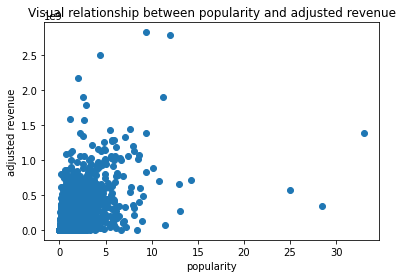

```python
plt.scatter(x=df.popularity,y=df.revenue_adj);
plt.title('Visual relationship between popularity and adjusted revenue')
plt.xlabel('popularity')
plt.ylabel('adjusted revenue')
```

The above plot shows a positive correlation between popularity and revenue.

### Research Question 2 - Which of the casts have the most popularity?

I seek to find out the top 10 cast with high popularity

From the dataset I observed there are a lot of different casts based on each movie.

From the list of cast I would like to investigate and find out who has the most popularity. Since there are a large number of casts to deal with in order to avoid duplication we would have to explode the cast index

```python
# Exploding a dataset helps to transform each element of list-like to a row, replicating the index values.

castdf=df.assign(cast=df['cast'].str.split('|')).explode('cast')
```

```python
rank_by_cast=castdf.groupby('cast',as_index=False)['popularity'].mean()
```

```python
# We would further rank the actors since our focus will be on the top 10 with huge popularity

top_10=rank_by_cast.sort_values(by='popularity',ascending=False).head(10)
top_10
```

|  | cast | popularity |
| --- | --- | --- |
| 9429 | Josh Helman | 28.419936 |
| 3898 | Daisy Ridley | 11.173104 |
| 7182 | Hugh Keays-Byrne | 10.211471 |
| 4037 | Daniel Henney | 8.691294 |
| 15889 | Ryan Potter | 8.691294 |
| 2344 | Brian Dobson | 8.411577 |
| 6569 | Gloria Foster | 7.753899 |
| 1229 | Ansel Elgort | 7.703183 |
| 2069 | Blake Cooper | 7.137273 |
| 10341 | Ki Hong Lee | 7.137273 |

#### We would further visualize the output on a graph to give a proper view and better understanding

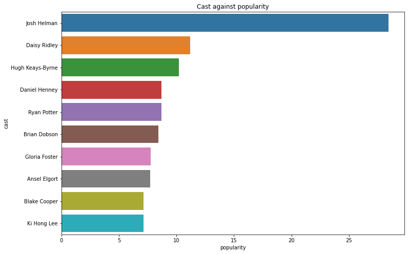

```python
# Plotting the graph

plot_bargraph(top_10['popularity'],top_10['cast'], 'Cast against popularity','popularity','cast')
```

#### Explaining the graph

- From the graph Josh Helman has the highest popularity.
- He is followed by Daisy Ridley and Hugh Keays-Byrne respectively
- Ryan Potter and Daniel Henney come up next on level of popularity
- They are followed by Brian Dobson
- Brian Dobson is followed by Gloria Foster and Ansel Elgort who are level on popularity.
- Ki Hong Lee and Blake Cooper end the list of top 10 also level on popularity.

### Research Question 3 - Who among the casts generated the most revenue?

I would like to investigate the top 10 cast with highest revenue

```python
# From the dataset I observed there are a lot of different casts based on each movie.
```

```python
# From the list of cast I would like to investigate and find out who brings in the most revenue.
# Since there are a large number of casts to deal with in order to avoid duplication I would have to explode the cast index

rank_by_cast=castdf.groupby('cast',as_index=False)['revenue_adj'].mean()
```

```python
# I have exploded the cast already in Q2 so we would rank the actors with our focus on the top 10 with the most revenue


top_10=rank_by_cast.sort_values(by='revenue_adj',ascending=False).head(10)
top_10
```

|  | cast | revenue_adj |
| --- | --- | --- |
| 3898 | Daisy Ridley | 1.902723e+09 |
| 15401 | Robert MacNaughton | 1.791694e+09 |
| 1918 | Betty Lou Gerson | 1.574815e+09 |
| 7453 | J. Pat O'Malley | 1.574815e+09 |
| 1826 | Ben Wright | 1.574815e+09 |
| 12015 | Martha Wentworth | 1.574815e+09 |
| 2122 | Bob Peck | 1.388863e+09 |
| 11321 | Louis Prima | 1.345551e+09 |
| 15168 | Richard S. Castellano | 1.277914e+09 |
| 16128 | Santino Fontana | 1.192711e+09 |

#### I would further visualize the output on a graph to give a proper view and better understanding

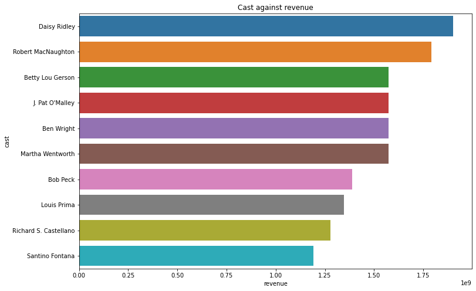

```python
# Plotting the graph

plot_bargraph(top_10['revenue_adj'],top_10['cast'], 'Cast against revenue','revenue','cast')
```

- From the graph we observed that amongst the top 10 cast Daisy Ridley brought in the most revenue.
- He is followed closely by Robert MacNaughton in terms of revenue generation.
- Betty Lou Gerson, Ben Wright, J Pat O'Malley and Martha Wentworth are level on popularity and raked in the same amount of revenue
- Bob Peck, Louis Prima and Richard S. Castellano follow accordingly in that order.
- The list concludes with Santino Fontano bringing the least revenue amongst the top 10 casts in scope

### QUESTION 4: What are the leading movies based on revenue and budget?

I would like to investigate the top 10 movies which topped in terms of revenue and budget

```python
# I will sort out the movie with regards to the one with the highest revenue to the one with the least in that order

top_10=df[['original_title','revenue_adj']].sort_values(by='revenue_adj',ascending=False).head(10)
top_10
```

|  | original_title | revenue_adj |
| --- | --- | --- |
| 1386 | Avatar | 2.827124e+09 |
| 1329 | Star Wars | 2.789712e+09 |
| 5231 | Titanic | 2.506406e+09 |
| 10594 | The Exorcist | 2.167325e+09 |
| 9806 | Jaws | 1.907006e+09 |
| 3 | Star Wars: The Force Awakens | 1.902723e+09 |
| 8889 | E.T. the Extra-Terrestrial | 1.791694e+09 |
| 8094 | The Net | 1.583050e+09 |
| 10110 | One Hundred and One Dalmatians | 1.574815e+09 |
| 4361 | The Avengers | 1.443191e+09 |

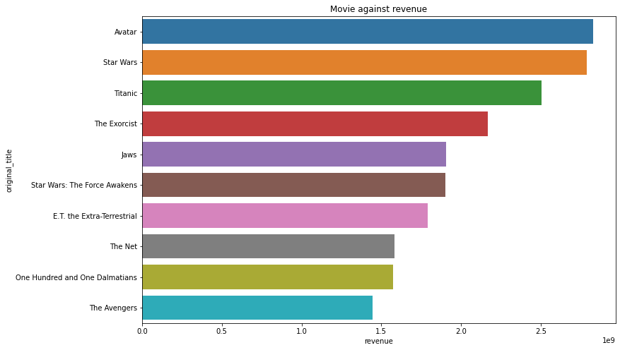

```python
# Plotting the graph

plot_bargraph(top_10['revenue_adj'],top_10['original_title'], 'Movie against revenue','revenue','original_title')
```

- From the graph it is observed that Avatar made the highest revenue.
- It was followed closly by Star Wars.
- Titanic followed up along with The Exorcist respectively.
- Jaws and Star Wars: The Force Awakens follows in a tied position in terms of revenue generation.
- E.T the Extra Terrestrials comes up nest after the tie
- The Net and One Hundred and One Dalmatians follows E.T the Extra Terrestrials and also are tied in terms of revenue
- The Avengers ends the list of top 10 in terms of revenue generation

###### Movies and adjusted budget analysis

```python
top_10=df[['original_title','budget_adj']].sort_values(by='budget_adj',ascending=False).head(10)
top_10
```

|  | original_title | budget_adj |
| --- | --- | --- |
| 2244 | The Warrior's Way | 4.250000e+08 |
| 3375 | Pirates of the Caribbean: On Stranger Tides | 3.683713e+08 |
| 7387 | Pirates of the Caribbean: At World's End | 3.155006e+08 |
| 6570 | Superman Returns | 2.920507e+08 |
| 5231 | Titanic | 2.716921e+08 |
| 7394 | Spider-Man 3 | 2.713305e+08 |
| 1929 | Tangled | 2.600000e+08 |
| 14 | Avengers: Age of Ultron | 2.575999e+08 |
| 1389 | Harry Potter and the Half-Blood Prince | 2.541001e+08 |
| 8089 | Waterworld | 2.504192e+08 |

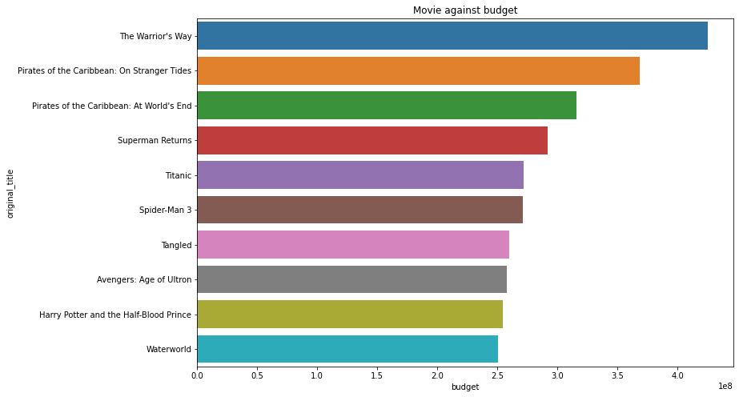

```python
# Plotting the graph

plot_bargraph(top_10['budget_adj'],top_10['original_title'], 'Movie against budget','budget','original_title')
```

- The Warrior's Way leads the top ten in terms of budget
- This is followed by Pirates of the Caribbean: On Stranger Tides.
- Pirates of the Caribbean: At World's End and Superman Returns continues on the list respectively
- Along comes Titanic and Spiderman-3 which are tied in therms of budget.
- Tangled, Avengers: Age of Ultron and Harry Potter and the Half-blood Prince continues the list in succession.
- Waterworld ends the list oh top 10 in terms of budget.

```python
from subprocess import call
call(['python', '-m', 'nbconvert', 'Investigate_a_Dataset.ipynb'])
```

```
0
```